# Yarra River Water Quality Analysis

Author

AWADHESHKUMAR THAKKAR

Published

September 1, 2025

```
[conflicted] Will prefer dplyr::filter over any other package.
[conflicted] Will prefer dplyr::select over any other package.
[conflicted] Will prefer dplyr::slice over any other package.
```

## Load the Libraries

```r
library(tidyverse)
library(dplyr)
library(lubridate)

set.seed(1234)
```

## Question 1

```r
#Reading the data
getwd()
```

```
[1] "C:/Github"
```

```r
library(readxl)
#reading the data and metadata and viewing it
yarra_wq <- read_excel("data/yarra_wq.xls")
#View(yarra_wq) please uncomment to view.
metadata <- read_csv("data/SW Metadata.csv")
#View(metadata) commented out to knit. KINDLY UNCOMMENT TO VIEW
str(yarra_wq) #check data types
```

```
tibble [16,383 × 10] (S3: tbl_df/tbl/data.frame)
 $ Site ID            : num [1:16383] 229108 229108 229108 229108 229108 ...
 $ Name               : chr [1:16383] "YARRA DS MCMAHONS" "YARRA DS MCMAHONS" "YARRA DS MCMAHONS" "YARRA DS MCMAHONS" ...
 $ Datetime           : POSIXct[1:16383], format: "1962-06-15 00:00:00" ...
 $ Data Type          : chr [1:16383] "Quantity" "Quantity" "Quantity" "Quantity" ...
 $ Parameter ID       : num [1:16383] 142 142 142 142 142 ...
 $ Parameter          : chr [1:16383] "Streamflow (mean daily)" "Streamflow (mean daily)" "Streamflow (mean daily)" "Streamflow (mean daily)" ...
 $ Value              : num [1:16383] 80 84 95 227 223 136 252 201 191 141 ...
 $ Unit of Measurement: chr [1:16383] "ML/day" "ML/day" "ML/day" "ML/day" ...
 $ Quality            : num [1:16383] 1 1 1 1 1 1 1 1 1 1 ...
 $ Resolution         : chr [1:16383] "Raw Data" "Raw Data" "Raw Data" "Raw Data" ...
```

```r
colSums(is.na(yarra_wq)) #check for NA values
```

```
            Site ID                Name            Datetime
                  0                   0                2271
          Data Type        Parameter ID           Parameter
                  0                   0                   0
              Value Unit of Measurement             Quality
                  0                   0                   0
         Resolution
                  0
```

```r
sum(is.na(yarra_wq$Datetime)) #
```

```
[1] 2271
```

```r
range(yarra_wq$Datetime, na.rm = TRUE)
```

```
[1] "1962-06-15 00:00:00 UTC" "2025-03-26 10:50:00 UTC"
```

```r
table(lubridate::year(yarra_wq$Datetime), useNA = "ifany")
```

```
1962 1963 1964 1965 1966 1967 1968 1969 1970 1971 1972 1973
 198  352  356  362  362  353  338  362  365  361  341  297
1974 1975 1976 1977 1978 1979 1980 1981 1982 1991 1992 1993
 436  863 1347 1280 1377 1056 1097  985    5   60  120  132
1994 2020 2021 2022 2023 2024 2025 <NA>
 110  197  173  155  184  351  137 2271
```

```r
# Step 1: Remove rows with NA in Datetime
yarra_wq <- yarra_wq %>%
  filter(!is.na(Datetime))

# Step 2: Convert Datetime to date-time components
yarra_wq <- yarra_wq %>%
  mutate(
    Year = year(Datetime),
    Month = month(Datetime),
    Weekday = wday(Datetime, label = TRUE),
    Hour = hour(Datetime)
  )

# Count records by year
yarra_wq %>%
  count(Year) %>%
  filter(Year >= 2000 & Year <= 2019)
```

```
# A tibble: 0 × 2
# ℹ 2 variables: Year <dbl>, n <int>
```

```r
# Step 3: Filter data for years from 1990 onwards as asked in qn
yarra_wq_clean <- yarra_wq %>%
  filter(Year >= 1990)
```

*checking which sites have sufficient data*

```r
#which sites/parameters have sufficient data?
site_counts <- yarra_wq_clean %>%
  group_by(`Site ID`, Name) %>%
  summarise(RecordCount = n(), .groups = "drop") %>%
  arrange(desc(RecordCount)) %>%
  print(n=Inf)
```

```
# A tibble: 1 × 3
  `Site ID` Name                 RecordCount
      <dbl> <chr>                      <int>
1    229143 YARRA @ CHANDLER HWY        1619
```

```r
site_counts
```

```
# A tibble: 1 × 3
  `Site ID` Name                 RecordCount
      <dbl> <chr>                      <int>
1    229143 YARRA @ CHANDLER HWY        1619
```

```r
parameter_counts <- yarra_wq_clean %>%
  group_by(`Parameter ID`, Parameter) %>%
  summarise(RecordCount = n(), .groups = "drop") %>%
  arrange(desc(RecordCount)) %>%
  print(n=Inf)
```

```
# A tibble: 22 × 3
   `Parameter ID` Parameter                      RecordCount
            <dbl> <chr>                                <int>
 1            210 pH                                     225
 2            450 Water Temperature                      225
 3            820 Salinity as EC@25                      225
 4            810 Turbidity                              221
 5           2332 Nitrogen as Nitrite (NO3)               53
 6           2337 Nitrogen as Total                       53
 7           2364 Phosphorus as TRP                       53
 8           2521 Total Arsenic                           53
 9           2571 Total Cadmium                           53
10           2601 Total Chromium                          53
11           2621 Total Copper                            53
12           2741 Total Nickel                            53
13           2821 Total Zinc                              53
14            215 Dissolved Oxygen (DO) (field)           46
15           2336 Nitrogen as Total Kjeldahl (T…          34
16           2363 Phosphorus (Total)                      34
17           2054 Colour (True Filtered) (PCU)            32
18           2172 Total Suspended Solids (TSS)            32
19           2333 Nitrogen as NOx                         32
20           2374 Phosphorus as FRP                       32
21           2331 Nitrogen as Nitrate (NO2)                2
22           2335 Nitrogen as Ammonia (Total)              2
```

```r
parameter_counts
```

```
# A tibble: 22 × 3
   `Parameter ID` Parameter                 RecordCount
            <dbl> <chr>                           <int>
 1            210 pH                                225
 2            450 Water Temperature                 225
 3            820 Salinity as EC@25                 225
 4            810 Turbidity                         221
 5           2332 Nitrogen as Nitrite (NO3)          53
 6           2337 Nitrogen as Total                  53
 7           2364 Phosphorus as TRP                  53
 8           2521 Total Arsenic                      53
 9           2571 Total Cadmium                      53
10           2601 Total Chromium                     53
# ℹ 12 more rows
```

```r
#checking the ranges of all parameters to ensure data quality
yarra_wq_clean %>%
  group_by(Parameter) %>%
  summarise(min_val = min(Value, na.rm = TRUE),
            max_val = max(Value, na.rm = TRUE))
```

```
# A tibble: 22 × 3
   Parameter                        min_val max_val
   <chr>                              <dbl>   <dbl>
 1 Colour (True Filtered) (PCU)      20     130
 2 Dissolved Oxygen (DO) (field)      0      14
 3 Nitrogen as Ammonia (Total)        0       0
 4 Nitrogen as NOx                    0.25    0.87
 5 Nitrogen as Nitrate (NO2)          0.39    0.51
 6 Nitrogen as Nitrite (NO3)          0.002   0.014
 7 Nitrogen as Total                  0.49    3
 8 Nitrogen as Total Kjeldahl (TKN)   0.3     1.2
 9 Phosphorus (Total)                 0.04    0.2
10 Phosphorus as FRP                  0.006   0.08
# ℹ 12 more rows
```

```r
#filtering out row with 0 pH as not physically plausible
yarra_wq_clean <- yarra_wq_clean %>%
  filter(!(Parameter == "pH" & Value == 0))

#filtering out rows that show no variation at all.
yarra_wq_clean <- yarra_wq_clean %>%
  filter(!Parameter %in% c("Nitrogen as Ammonia (Total)",
                           "Phosphorus as TRP",
                           "Total Cadmium"))

#View(yarra_wq_clean)

glimpse(yarra_wq_clean)
```

```
Rows: 1,509
Columns: 14
$ `Site ID`             <dbl> 229143, 229143, 229143, 2291…
$ Name                  <chr> "YARRA @ CHANDLER HWY", "YAR…
$ Datetime              <dttm> 1992-03-10 09:50:00, 1992-0…
$ `Data Type`           <chr> "Quality", "Quality", "Quali…
$ `Parameter ID`        <dbl> 2054, 2054, 2054, 2054, 2054…
$ Parameter             <chr> "Colour (True Filtered) (PCU…
$ Value                 <dbl> 35, 45, 40, 50, 75, 35, 90, …
$ `Unit of Measurement` <chr> "Pt-Co", "Pt-Co", "Pt-Co", "…
$ Quality               <dbl> 65, 65, 65, 65, 65, 65, 65, …
$ Resolution            <chr> "Raw Data", "Raw Data", "Raw…
$ Year                  <dbl> 1992, 1992, 1992, 1992, 1992…
$ Month                 <dbl> 3, 4, 5, 6, 7, 8, 9, 10, 11,…
$ Weekday               <ord> Tue, Wed, Tue, Wed, Tue, Tue…
$ Hour                  <int> 9, 11, 9, 11, 11, 10, 9, 11,…
```

```r
yarra_wq_clean %>%
  group_by(Parameter) %>%
  summarise(
    q1 = quantile(Value, 0.25, na.rm = TRUE),
    median = median(Value, na.rm = TRUE),
    q3 = quantile(Value, 0.75, na.rm = TRUE),
    max = max(Value, na.rm = TRUE)
  )
```

```
# A tibble: 19 × 5
   Parameter                       q1  median      q3    max
   <chr>                        <dbl>   <dbl>   <dbl>  <dbl>
 1 Colour (True Filtered) (P…  35      40      62.5   1.3e+2
 2 Dissolved Oxygen (DO) (fi…   7.6     9      10.1   1.4e+1
 3 Nitrogen as NOx              0.428   0.515   0.658 8.7e-1
 4 Nitrogen as Nitrate (NO2)    0.42    0.45    0.48  5.1e-1
 5 Nitrogen as Nitrite (NO3)    0.003   0.004   0.007 1.4e-2
 6 Nitrogen as Total            0.83    0.98    1.1   3  e+0
 7 Nitrogen as Total Kjeldah…   0.4     0.5     0.78  1.2e+0
 8 Phosphorus (Total)           0.07    0.095   0.13  2  e-1
 9 Phosphorus as FRP            0.01    0.02    0.04  8  e-2
10 Salinity as EC@25          150     180     220     1.3e+3
11 Total Arsenic                0.001   0.001   0.001 5  e-3
12 Total Chromium               0.001   0.002   0.002 1.6e-2
13 Total Copper                 0.002   0.002   0.003 1.4e-2
14 Total Nickel                 0.001   0.002   0.003 1.3e-2
15 Total Suspended Solids (T…  30      44.5    70     5.6e+2
16 Total Zinc                   0.01    0.013   0.018 8.5e-2
17 Turbidity                   18      24      37     3.4e+2
18 Water Temperature           12.4    18.4    22     2.6e+1
19 pH                           7       7.2     7.5   9.3e+0
```

```r
yarra_wq_clean %>%
  count(Year, Parameter)
```

```
# A tibble: 107 × 3
    Year Parameter                            n
   <dbl> <chr>                            <int>
 1  1991 Dissolved Oxygen (DO) (field)       12
 2  1991 Salinity as EC@25                   12
 3  1991 Turbidity                           12
 4  1991 Water Temperature                   12
 5  1991 pH                                  11
 6  1992 Colour (True Filtered) (PCU)        10
 7  1992 Dissolved Oxygen (DO) (field)       12
 8  1992 Nitrogen as NOx                     10
 9  1992 Nitrogen as Total Kjeldahl (TKN)    10
10  1992 Phosphorus (Total)                  10
# ℹ 97 more rows
```

After inspecting the raw dataset, we found that 2271 rows had missing or invalid Datetime values, and that the data spanned 1962-2025.

As the research question focuses on whether water quality has declined from the 1990s to recent years, we excluded all rows with missing datetimes and restricted dataset to observations from 1990 onwards. Some sites had records with missing datetime values, even though metadata indicated they were active after 1990. because the timing of these measurements could not be reliably determined, these rows were excluded.we also derived additional time components (Year, Month, Weekday, Hour) for later analysis.

```r
# Save the cleaned dataset
# This ensures reproducibility and allows later questions to use the same cleaned data

readr::write_csv(yarra_wq_clean, "yarra_wq_clean.csv")
```

## Question 2

```r
#understanding what the quality variable is
yarra_wq_clean %>% count(Quality)
```

```
# A tibble: 3 × 2
  Quality     n
    <dbl> <int>
1       2  1089
2      65   412
3     180     8
```

```r
yarra_wq_clean %>%
  filter(Quality == 180) %>%
  select(`Site ID`, Name, Datetime, Year, Parameter, Value, Quality)
```

```
# A tibble: 8 × 7
  `Site ID` Name   Datetime             Year Parameter Value
      <dbl> <chr>  <dttm>              <dbl> <chr>     <dbl>
1    229143 YARRA… 1991-06-11 10:25:00  1991 Dissolve…     0
2    229143 YARRA… 1994-02-16 11:40:00  1994 Dissolve…     0
3    229143 YARRA… 1991-08-06 12:15:00  1991 Salinity…     0
4    229143 YARRA… 1992-02-05 12:50:00  1992 Salinity…     0
5    229143 YARRA… 1994-01-19 11:50:00  1994 Salinity…     0
6    229143 YARRA… 1991-07-03 12:40:00  1991 Turbidity     0
7    229143 YARRA… 1992-02-05 12:50:00  1992 Turbidity     0
8    229143 YARRA… 1994-01-19 11:50:00  1994 Turbidity     0
# ℹ 1 more variable: Quality <dbl>
```

```r
glimpse(metadata)
```

```
Rows: 10
Columns: 28
$ `Site ID`                        <dbl> 229108, 229142, 2…
$ Name                             <chr> "YARRA RIVER @ D/…
$ `Short Name`                     <chr> "YARRA DS MCMAHON…
$ Latitude                         <chr> "37\xb042'48.0\"S…
$ Longitude                        <chr> "145\xb048'54.0\"…
$ `Geographic Coordinate System`   <chr> "Unknown", "Geode…
$ Easting                          <dbl> 395554, 335779, 3…
$ Northing                         <dbl> 5825315, 5821382,…
$ Zone                             <dbl> 55, 55, 55, 55, 5…
$ `Start date`                     <date> 1962-06-13, 1975…
$ `Cease date`                     <date> 1983-02-01, 1982…
$ Active                           <lgl> FALSE, FALSE, FAL…
$ `Elevation (m)`                  <dbl> 227, 22, 25, 72, …
$ Basin                            <chr> "Yarra", "Yarra",…
$ `Site types`                     <chr> NA, NA, "SW,WQ", …
$ `Catchment Management Authority` <chr> NA, NA, "Melbourn…
$ `Gauge Zero (mAHD)`              <dbl> 210, 0, 0, 0, 0, …
$ `Drainage Area (sq.km)`          <dbl> 467, 2705, 3290, …
$ `Gauge Count`                    <dbl> NA, NA, 20, 28, N…
$ `Last Gauge Date`                <date> NA, NA, 2004-08-…
$ `First Gauge Date`               <date> NA, NA, 1974-05-…
$ `Maximum Gauge (m)`              <dbl> 2.52, 8.32, 8.35,…
$ `Maximum Gauge Date`             <date> 1971-10-05, 1971…
$ `Gauge Datum`                    <chr> "Unknown", "(unkn…
$ Control                          <chr> "NATURAL GRAVEL",…
$ `Cease to flow (m)`              <dbl> 0.000, 0.000, 0.0…
$ Datum                            <chr> "Arbitrary", "Aus…
$ `Spillway (mAHD)`                <dbl> 0, 0, 0, 0, 0, 0,…
```

```r
# Count records by year
yarra_wq_clean %>%
  count(Year) %>%
  filter(Year >= 2000 & Year <= 2019)
```

```
# A tibble: 0 × 2
# ℹ 2 variables: Year <dbl>, n <int>
```

*although metadata indicates that some sites were still active in the 2000s, no water quality measurements are available in the dataset for 2000-2019. As a result, my comparisons are limited to the 1990s versus the 2020s.*

```r
#creating a period variable to differentiate qualiy between years
yarra_wq_clean <- yarra_wq_clean %>%
  mutate(
    period = case_when(
      Year >= 1990 & Year <= 1999 ~ "1990s",
      Year >= 2020 ~ "2020s",
      TRUE ~ "Other"
    )
  )
```

```r
yarra_wq_clean %>%
  group_by(Parameter, period) %>%
  summarise(mean_val = mean(Value, na.rm = TRUE),
            sd_val   = sd(Value, na.rm = TRUE),
            n = n())
```

```
# A tibble: 25 × 5
# Groups:   Parameter [19]
   Parameter                   period mean_val  sd_val     n
   <chr>                       <chr>     <dbl>   <dbl> <int>
 1 Colour (True Filtered) (PC… 1990s  50.9     2.68e+1    32
 2 Dissolved Oxygen (DO) (fie… 1990s   8.67    2.53e+0    46
 3 Nitrogen as NOx             1990s   0.545   1.53e-1    32
 4 Nitrogen as Nitrate (NO2)   2020s   0.45    8.49e-2     2
 5 Nitrogen as Nitrite (NO3)   2020s   0.00536 2.94e-3    53
 6 Nitrogen as Total           2020s   1.05    4.15e-1    53
 7 Nitrogen as Total Kjeldahl… 1990s   0.588   2.64e-1    32
 8 Nitrogen as Total Kjeldahl… 2020s   0.96    3.39e-1     2
 9 Phosphorus (Total)          1990s   0.102   4.44e-2    32
10 Phosphorus (Total)          2020s   0.14    1.41e-2     2
# ℹ 15 more rows
```

Above mean based summaries show mixed evidence of change, pH increased sightly from 6.9 in 1990s to 7.4 in the 2020s, while turbidity interestinglty declined (from 47 n 1990s to 38 NTU in 2020s). Water temperatures have risen from 15C in 1990s to 18 degrees Celcius in 2020s.

```r
yarra_wq_clean %>%
  group_by(Parameter, period) %>%
  summarise(median_val = median(Value, na.rm = TRUE),
            iqr_val    = IQR(Value, na.rm = TRUE))
```

```
# A tibble: 25 × 4
# Groups:   Parameter [19]
   Parameter                      period median_val  iqr_val
   <chr>                          <chr>       <dbl>    <dbl>
 1 Colour (True Filtered) (PCU)   1990s      40     27.5
 2 Dissolved Oxygen (DO) (field)  1990s       9      2.47
 3 Nitrogen as NOx                1990s       0.515  0.23
 4 Nitrogen as Nitrate (NO2)      2020s       0.45   0.06
 5 Nitrogen as Nitrite (NO3)      2020s       0.004  0.004
 6 Nitrogen as Total              2020s       0.98   0.27
 7 Nitrogen as Total Kjeldahl (T… 1990s       0.5    0.25
 8 Nitrogen as Total Kjeldahl (T… 2020s       0.96   0.240
 9 Phosphorus (Total)             1990s       0.09   0.045
10 Phosphorus (Total)             2020s       0.14   0.01000
# ℹ 15 more rows
```

In our median based summaries, we can see the findings being reinforced. pH has shifted upwards from 6.9 in 1990s to 7.3 in 2020s. interestingly, again turbidity has seen a decline at 29.5 in 1990s to median 23 in 2020s. this could reflect improved river management, wastewater treatment upgrades. However, since our dataset covers only one monitoring site (Chandler Hwy) and lacks records from 2000-2019, this apparent improvement should be interpreted cautiously. The median temperature has increased again from 1990s to 2020s. Nitrogen as Total Kjedahl was more commonly measured in 1990s as shown above in the n values as TKN values for 2020s are sparse.

Some parameters (eg dissolved oxygen) were only measured in 1990s, while others eg metals like arsenic, chromium were only measured in 2020s. These parameters cannot be compared across decades, limiting their ability to assess long-term change for these indicators.

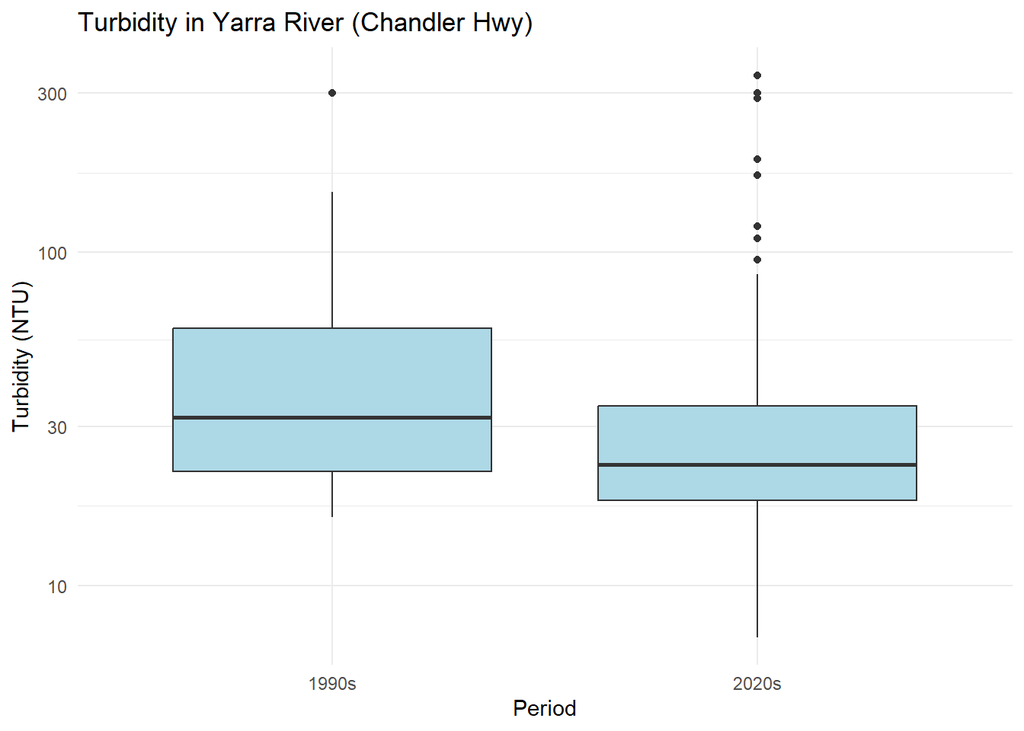

```r
#Boxplot by decade.
ggplot(
  yarra_wq_clean %>% filter(Parameter == "Turbidity"),
  aes(x = period, y = Value)
) +
  geom_boxplot(fill = "lightblue") +
  scale_y_continuous(trans = "log10") + # use log scale if outliers are huge
  labs(title = "Turbidity in Yarra River (Chandler Hwy)",
       x = "Period", y = "Turbidity (NTU)") +
  theme_minimal()
```

Annual turbidity vs year plot

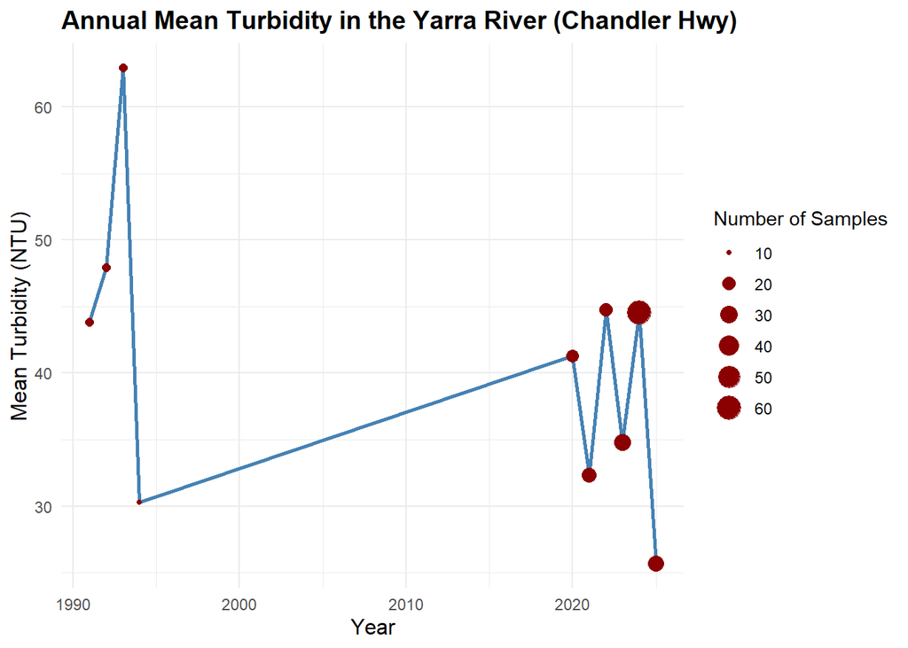

```r
#Aggregate turbiditiy by year.
turbidity_yearly <- yarra_wq_clean %>%
  # Keep only Turbidity values
  filter(Parameter == "Turbidity") %>%
  # Group by year of measurement
  group_by(Year) %>%
  # Calculate summary stats per year
  summarise(
    mean_val = mean(Value, na.rm = TRUE),      # yearly mean
    median_val = median(Value, na.rm = TRUE),  # yearly median
    n = n(),                                   # number of samples per year
    .groups = "drop"
  )

# Plot mean turbidity by year
ggplot(turbidity_yearly, aes(x = Year, y = mean_val)) +
  geom_line(color = "steelblue", linewidth = 1) +
  geom_point(aes(size = n), color = "darkred") +      # point size shows how many samples per year
  labs(
    title = "Annual Mean Turbidity in the Yarra River (Chandler Hwy)",
    x = "Year",
    y = "Mean Turbidity (NTU)",
    size = "Number of Samples"
  ) +
  theme_minimal() +
  theme(
    plot.title = element_text(face = "bold", size = 14),
    axis.title = element_text(size = 12)
  )
```

Turbidity results are illustrated in two complementary ways. a boxplot comparison (1990s vs 2020s) highlights a decline in central tendenc. However, outliers remain in both the decades, and this reflects episodic storm events. the annual plot shows year to year variability and a clear 2 decade gap between 2000-2019.

**side by side boxplots of different parameters**

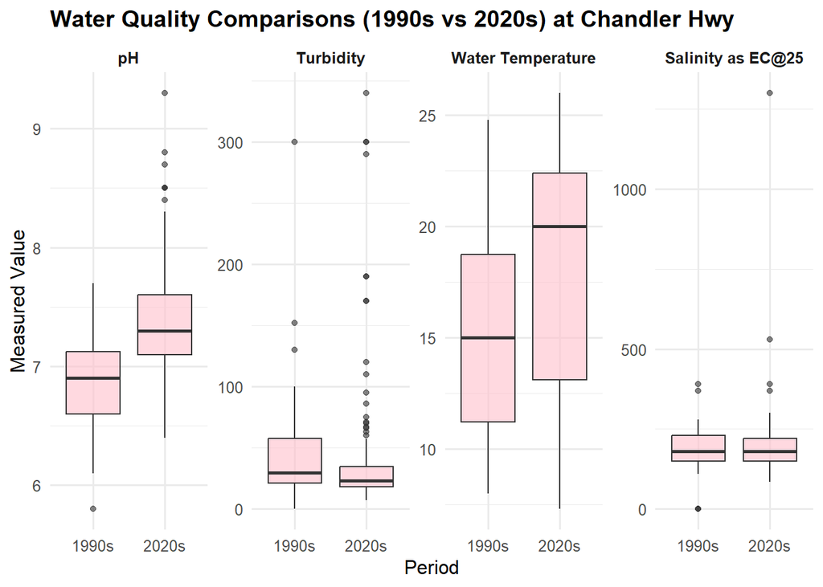

```r
#  Picking a compact set of core parameters to compare side-by-side
core_params <- c("pH", "Turbidity", "Water Temperature", "Salinity as EC@25")

# Filter to those parameters and tidy factor order for nicer facets
plot_box <- yarra_wq_clean %>%
  filter(Parameter %in% core_params) %>%
  mutate(
    Parameter = fct_relevel(Parameter, "pH", "Turbidity", "Water Temperature", "Salinity as EC@25"),
    period = fct_relevel(period, "1990s", "2020s")
  )

#  Build the faceted boxplot (free y-scale per parameter)
ggplot(plot_box, aes(x = period, y = Value)) +
  geom_boxplot(fill = "pink", alpha = 0.6, outlier.alpha = 0.6) +
  facet_wrap(~ Parameter, scales = "free_y", nrow = 1) +
  labs(
    title = "Water Quality Comparisons (1990s vs 2020s) at Chandler Hwy",
    x = "Period",
    y = "Measured Value"
  ) +
  theme_minimal(base_size = 12) +
  theme(
    plot.title = element_text(face = "bold"),
    strip.text = element_text(face = "bold")
  )
```

the above figure compares 4 core indicators (pH, turbidity, water temperature, salinity) across the 1990s and 2020s at Chandler Hwy. The 2020s data show slightly higher pH values, lower turbidity and variability, and clear upward shift in water temperature, consistent with climate warning. salinity distributions have remained pretty similar although we have few outliers as well.

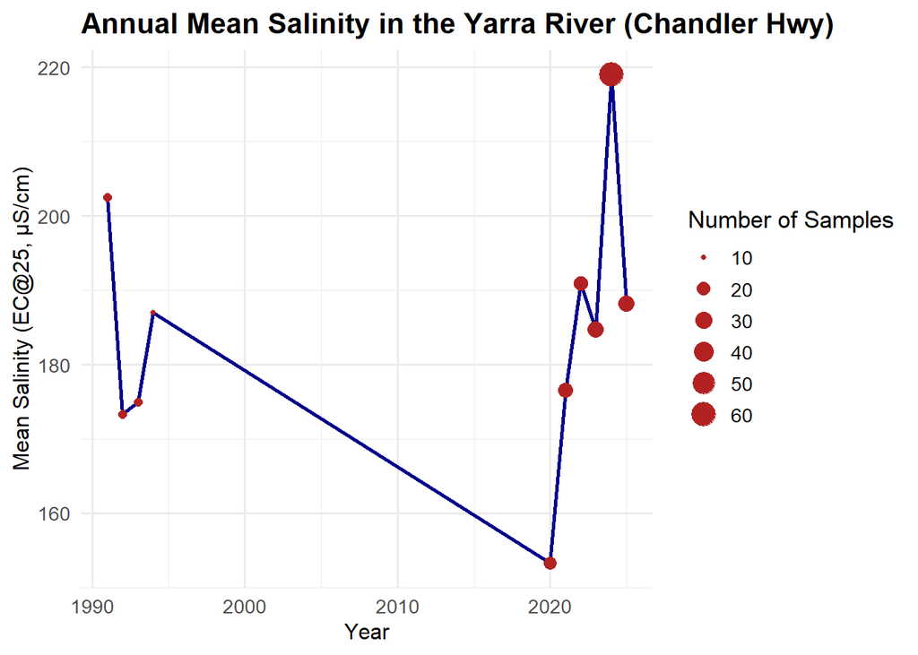

```r
salinity_yearly <- yarra_wq_clean %>%
  filter(Parameter == "Salinity as EC@25") %>%    # keep only salinity
  group_by(Year) %>%
  summarise(
    mean_val = mean(Value, na.rm = TRUE),         # yearly mean salinity
    median_val = median(Value, na.rm = TRUE),     # yearly median salinity
    n = n(),                                      # number of samples per year
    .groups = "drop"
  )

# Plot annual mean salinity with number of samples ---
ggplot(salinity_yearly, aes(x = Year, y = mean_val)) +
  geom_line(color = "darkblue", linewidth = 1) +         # line showing trend
  geom_point(aes(size = n), color = "firebrick") +       # point size ~ sample count
  labs(
    title = "Annual Mean Salinity in the Yarra River (Chandler Hwy)",
    x = "Year",
    y = "Mean Salinity (EC@25, µS/cm)",
    size = "Number of Samples"
  ) +
  theme_minimal(base_size = 13) +
  theme(
    plot.title = element_text(face = "bold"),
    axis.title = element_text(size = 12)
  )
```

```r
# Summary stats table by decade and parameter
yarra_wq_clean %>%
  filter(Parameter %in% c("pH", "Turbidity", "Water Temperature", "Salinity as EC@25")) %>%
  group_by(Parameter, period) %>%
  summarise(
    n = n(),
    mean_val = mean(Value, na.rm = TRUE),
    median_val = median(Value, na.rm = TRUE),
    iqr_val = IQR(Value, na.rm = TRUE),
    .groups = "drop"
  )
```

```
# A tibble: 8 × 6
  Parameter         period     n mean_val median_val iqr_val
  <chr>             <chr>  <int>    <dbl>      <dbl>   <dbl>
1 Salinity as EC@25 1990s     46   184.        180    80
2 Salinity as EC@25 2020s    179   193.        180    70
3 Turbidity         1990s     46    46.9        29.5  36.8
4 Turbidity         2020s    175    38.3        23    16.5
5 Water Temperature 1990s     46    15.2        15     7.55
6 Water Temperature 2020s    179    18.0        20     9.3
7 pH                1990s     44     6.87        6.9   0.525
8 pH                2020s    179     7.40        7.3   0.5
```

**1)Annual turbidity vs year plot.** Null Hypothesis based on the code- H0:E[turbidity∣Year]=μ for all years, i.e the annual mean turbiditiy is constant over time (no association between Year and annual mean.) Alternative Hypothesis: The annual mean turbidity changes with time. What visual feature would reject H0? - A non-flat trend in the line of annual means, not explainable by random fluctuation, especially when years with larger n also support the trend.

```r
#lineup for annual turbditiy

library(nullabor)
# Step 1: raw turbidity values
turb_raw <- yarra_wq_clean %>%
  filter(Parameter == "Turbidity")

# Step 2: lineup (permute Year under H0, then re-aggregate)
lineup_raw <- lineup(null_permute("Year"), turb_raw, n = 20)
```

```
decrypt("Efj3 zrAr Ni e6qNAN6i BT")
```

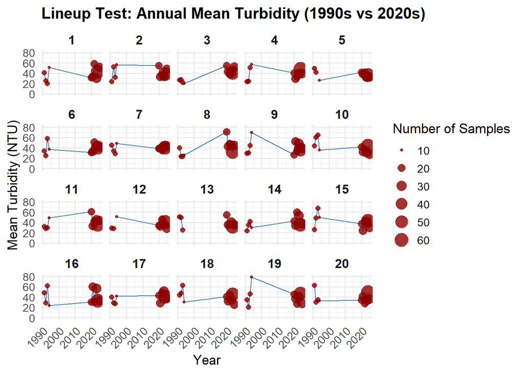

```r
lineup_yearly <- lineup_raw %>%
  group_by(.sample, Year) %>%
  summarise(
    mean_val = mean(Value, na.rm = TRUE),
    n        = n(),
    .groups  = "drop"
  )

# Step 3: Plot lineup  make panels bigger and axes cleaner
ggplot(lineup_yearly, aes(x = Year, y = mean_val)) +
  geom_line(color = "steelblue") +
  geom_point(aes(size = n), color = "darkred", alpha = 0.8) +
  facet_wrap(~ .sample, ncol = 5) +   # 4 rows × 5 columns = 20 panels
  scale_y_continuous(limits = c(0, 80)) +   # consistent y-axis
  labs(
    title = "Lineup Test: Annual Mean Turbidity (1990s vs 2020s)",
    x = "Year",
    y = "Mean Turbidity (NTU)",
    size = "Number of Samples"
  ) +
  theme_minimal(base_size = 13) +
  theme(
    plot.title = element_text(face = "bold", size = 15),
    strip.text = element_text(size = 12, face = "bold"),
    axis.text.x = element_text(angle = 45, hjust = 1) # readable years
  )
```

**2) pH boxplot comparison.** Null Hypothesis: H₀: The distribution of pH in the 1990s is the same as in the 2020s. Test idea: If H₀ is true, swapping the period labels (1990s vs 2020s) should not change the shape/position of the boxplots.

generating the lineup

```r
#generate the lineup.
#Step 1: filter pH only
ph_data <- yarra_wq_clean %>%
  filter(Parameter == "pH") %>%
  mutate(period = fct_relevel(period, "1990s", "2020s"))

#  Step 2: lineup with null_permute on 'period'
# Idea: under H0, period labels are exchangeable.
ph_lineup <- lineup(null_permute("period"), ph_data, n = 20)
```

```
decrypt("Efj3 zrAr Ni e6qNAN6i uu")
```

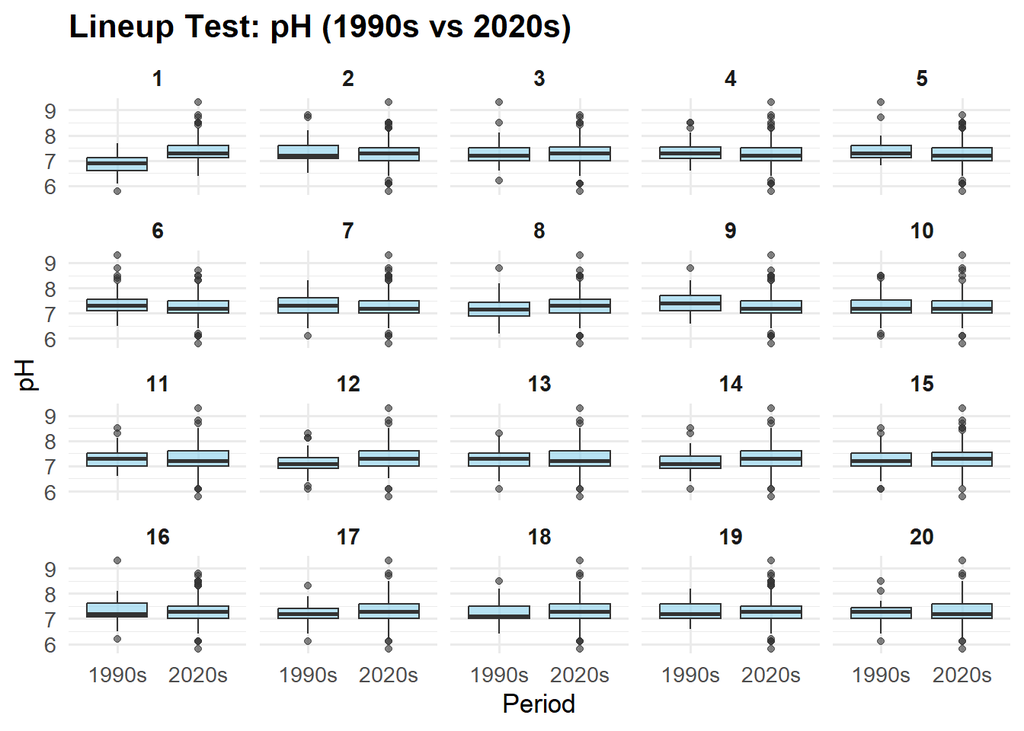

```r
#  Step 3: plot lineup
ggplot(ph_lineup, aes(x = period, y = Value)) +
  geom_boxplot(fill = "skyblue", alpha = 0.6, outlier.alpha = 0.6) +
  facet_wrap(~ .sample, ncol = 5) +
  labs(
    title = "Lineup Test: pH (1990s vs 2020s)",
    x = "Period",
    y = "pH"
  ) +
  theme_minimal(base_size = 13) +
  theme(
    plot.title = element_text(face = "bold"),
    strip.text = element_text(size = 11, face = "bold")
  )
```

Null generation: To test this, the period labels (1990s, 2020s) were permuted among pH values, and 19 null datasets were created. Together with the true dataset, these formed a lineup of 20 panels. Result: In the true dataset, the 2020s show a clear upward shift in pH compared to the 1990s. This pattern is not present in most null panels, which look more balanced. The lineup therefore supports rejecting the null, suggesting that pH has significantly increased over time.

**Water salinity plot.** Null hypothesis (H₀): The mean salinity (EC@25) at Chandler Hwy has remained constant over time, with no systematic difference between the 1990s and 2020s.

Null generation: To test this, the year labels were permuted across salinity measurements, and 19 null datasets were generated. Yearly means were recalculated for each, forming a lineup of 20 panels with one real dataset.

```r
#1) Use RAW salinity rows (not pre-aggregated)
sal_raw <- yarra_wq_clean %>%
  filter(Parameter == "Salinity as EC@25")

# 2) Generate lineup data: 19 null datasets + 1 true
#    Null method = permute Year on raw rows (breaks time structure under H0)
sal_lineup_raw <- lineup(null_permute("Year"), sal_raw, n = 20)
```

```
decrypt("Efj3 zrAr Ni e6qNAN6i u4")
```

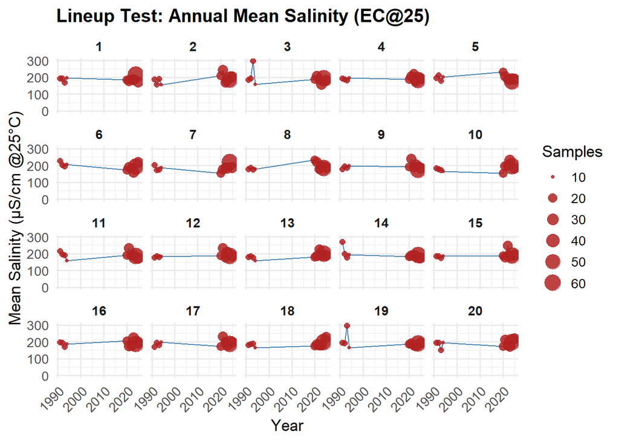

```r
# 3) Re-aggregate within each sample to annual means (what your plot shows)
sal_lineup_yearly <- sal_lineup_raw %>%
  group_by(.sample, Year) %>%
  summarise(
    mean_val = mean(Value, na.rm = TRUE),
    n        = n(),              # number of salinity measurements that year
    .groups  = "drop"
  )

# 4) Plot the lineup (20 panels). One is the TRUE dataset, others are nulls.
ggplot(sal_lineup_yearly, aes(x = Year, y = mean_val)) +
  geom_line(color = "steelblue") +
  geom_point(aes(size = n), color = "firebrick", alpha = 0.85) +
  facet_wrap(~ .sample, ncol = 5) +          # 4x5 grid = 20 panels
  scale_y_continuous(limits = c(0, NA)) +    # keep y >= 0; let top scale adapt
  labs(
    title = "Lineup Test: Annual Mean Salinity (EC@25)",
    x = "Year",
    y = "Mean Salinity (µS/cm @25°C)",
    size = "Samples"
  ) +
  theme_minimal(base_size = 13) +
  theme(
    plot.title = element_text(face = "bold", size = 15),
    strip.text  = element_text(face = "bold"),
    axis.text.x = element_text(angle = 45, hjust = 1)
  )
```

**I have made good use of R packages, mainly from tidyverse collection. dplyr and tidyr was mainly used for data cleaning and summarisation. ggplot2 was used for visualisation.**

The materials used for this report are:

Wickham H, Averick M, Bryan J, Chang W, McGowan LD, François R, Grolemund G, Hayes A, Henry L, Hester J, Kuhn M, Pedersen TL, Miller E, Bache SM, Müller K, Ooms J, Robinson D, Seidel DP, Spinu V, Takahashi K, Vaughan D, Wilke C, Woo K, Yutani H (2019). “Welcome to the tidyverse.” *Journal of Open Source Software*, *4*(43), 1686. [doi:10.21105/joss.01686](https://doi.org/10.21105/joss.01686).